# Analysis of Mental Health Prescribing Across SIMD Deprivation Quintiles in Scotland (2024)

2025-11-14

# Introduction

Mental health inequalities are a major and persistent public health issue in Scotland. Evidence consistently shows that people living in socioeconomically deprived areas experience higher rates of common mental disorders, including depression and anxiety, as well as more severe and enduring mental illness (Public Health Scotland, 2022). The Scottish Index of Multiple Deprivation (SIMD) provides an established framework for identifying the relative level of deprivation experienced by communities in Scotland. Previous research has shown that mental-health-related prescribing is higher in more deprived areas (Public Health Scotland, 2021), but GP-level patterns remain under-examined.Primary care prescribing offers an important indicator of both population mental health needs and healthcare response. Higher prescribing rates in more deprived communities may reflect increased clinical need, but could also reveal inequalities in access to non-pharmacological interventions such as psychological therapies. This analysis uses national “Prescriptions in the Community” data for 2024 to examine whether GP prescribing of mental health medications aligns with socioeconomic deprivation patterns. Specifically, it investigates whether prescribing rates differ across SIMD quintiles and whether a clear socioeconomic gradient is present across different medication classes and throughout the year.

```r
library(tidyverse)
library(here)
library(stringr)
```

### Loading Data Set

Data pitc202401 to pitc202412 were downloaded from: https://www.opendata.nhs.scot/dataset/prescriptions-in-the-community

```r
files_2024 <- list.files(
  here("data", "2024"),
  pattern = "^pitc2024[0-9]{2}\\.csv$", # match pitc202401-pitc202412 only
  full.names = TRUE # return full file paths
)
pitc2024_all <- map_dfr(files_2024, function(path) {
  pres <- read_csv(path, show_col_types = FALSE) # read each monthly csv
  if (!"DMDCode" %in% names(pres)) { #if DMDCode colomn missing,
    pres <- pres %>% mutate(DMDCode = NA_character_) # create it with NA
  }
  pres %>% mutate(DMDCode = as.character(DMDCode)) # ensure DMDCode is character type because in some monthly csv DMDCode is Double
})
```

SIMD Data Source: https://www.gov.scot/publications/scottish-index-of-multiple-deprivation-2020v2-postcode-look-up/

```r
GPlist_raw <- read_csv(here("data","practice_contactdetails_oct2024-open-data.csv"))
gp_info <- GPlist_raw %>%
  select(PracticeCode, GPPracticeName, Postcode, PracticeListSize) %>% # keep only variables needed for linking
  mutate( Postcode_clean = str_remove_all(Postcode, " ") %>% str_to_upper() # standardise postcode: no spaces, all upper-case
          )
simd_raw <- read_csv(here("data", "SIMD+2020v2+-+postcode+lookup+-+updated+2025.csv"))
simd_info <- simd_raw %>%
  mutate(
    Postcode_clean = str_remove_all(Postcode, " ") %>% str_to_upper() # standardise postcode format to match GP file
  ) %>%
  select( Postcode_clean, SIMD_quintile = SIMD2020_Quintile # rename SIMD_Quintile to SIMD_quintile
          )
```

### Join table

```r
gp_simd <- gp_info %>%
  left_join(simd_info, join_by("Postcode_clean")) # attach SIMD_quintile to each GP using cleaned postcode
pres_joined <- pitc2024_all %>%
  left_join(gp_simd %>%
      select(PracticeCode, GPPracticeName, PracticeListSize, SIMD_quintile), by = c("GPPractice" = "PracticeCode")) %>%
  mutate(month = PaidDateMonth %% 100) # extract calendar month from YYYYMM format
```

### Filtering Drugs

Drugs were confirmed according to BNFCode.

```r
mh_2024 <- pres_joined %>%
  filter(
    str_starts(BNFItemCode, "0401") |
    str_starts(BNFItemCode, "0402") |
    str_starts(BNFItemCode, "0403")
  ) %>%
  mutate(
    drug_class = case_when(
      str_starts(BNFItemCode, "0401") ~ "Anxiolytics/Hypnotics", # classify by BNF code prefix
      str_starts(BNFItemCode, "0402") ~ "Antipsychotics",
      str_starts(BNFItemCode, "0403") ~ "Antidepressants"
    )
  )
```

```r
mh_rate_gp_2024 <- mh_2024 %>%
  group_by(GPPractice, GPPracticeName, SIMD_quintile) %>%
  summarise(
    items = sum(NumberOfPaidItems, na.rm = TRUE), # total mental health items per GP in 2024
    list_size = first(PracticeListSize), # practice list size (assumed constant in 2024)
    .groups = "drop"
  ) %>%
  mutate(
    rate_per_1000 = items / list_size * 1000 #prescribing rate per 1000 registrated patients
  ) %>%
  filter(!is.na(SIMD_quintile)) # keep only practices with a SIMD quintile
```

# Results

Mental health prescribing patterns in 2024 were examined across Scottish GP practices by linking community prescribing data with SIMD deprivation classifications. For each practice, annual counts of BNF 04.01, 04.02 and 04.03 items were aggregated and standardised by practice list size to produce prescribing rates per 1000 registered patients. These rates formed the basis of all subsequent analyses. Deprivation-related differences were first explored descriptively using boxplots, monthly trend lines, and drug-class–specific comparisons (Figures 1–3). To formally quantify these patterns, multiple statistical approaches were applied. A Kruskal–Wallis test assessed overall variation across the five SIMD quintiles, and Bonferroni-adjusted post-hoc Dunn tests identified which specific quintile pairs differed significantly. The persistence of socioeconomic inequalities throughout the year was evaluated by repeating Kruskal–Wallis tests for each month of 2024, while additional analyses stratified by drug class determined whether inequalities were consistent across antidepressants, antipsychotics, and anxiolytics/hypnotics. Finally, a Pearson correlation was used to estimate the overall linear association between prescribing rate and SIMD quintile. Together, this combination of descriptive visualisation and inferential testing provides a comprehensive assessment of how socioeconomic deprivation shaped mental health prescribing across Scottish primary care in 2024.

### Plots

```r
pink_palette <- c(
  "1" = "#ffe4f0",  # most deprived
  "2" = "#ffb6d9",
  "3" = "#ff80ba",
  "4" = "#ff4b9b",
  "5" = "#d6006b"   # least deprived
) # set a theme palette color
```

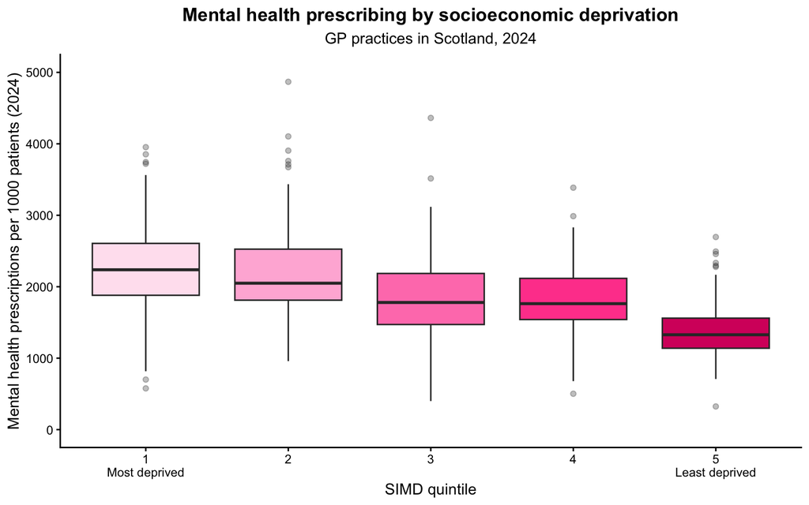

```r
ggplot(mh_rate_gp_2024,
       aes(x = factor(SIMD_quintile), y = rate_per_1000, fill = factor(SIMD_quintile))) +
  geom_boxplot(outlier.alpha = 0.3) +
  coord_cartesian(ylim = c(0, 5000)) + #Set the y-axis range to make the graph larger
  scale_fill_manual(
    values = pink_palette,
    name   = "SIMD quintile",
    labels = c("1 (most deprived)", "2", "3", "4", "5 (least deprived)")) + # fill the boxplot with the prepared palette
  scale_x_discrete(
    labels = c("1\nMost deprived", "2", "3", "4", "5\nLeast deprived")) + # Label the X axis
  labs(
    x = "SIMD quintile",
    y = "Mental health prescriptions per 1000 patients (2024)",
    title = "Mental health prescribing by socioeconomic deprivation",
    subtitle = "GP practices in Scotland, 2024"
  ) +
  theme_classic() +
  theme(plot.title    = element_text(hjust = 0.5, face = "bold"),
        plot.subtitle = element_text(hjust = 0.5),
        legend.position = "none")
```

Figure 1.Overall prescribing differences across SIMD quintiles. Across all GP practices in Scotland, mental health prescribing rates showed a strong socioeconomic gradient. Practices located in the most deprived SIMD quintile (Q1) had the highest prescribing rates, with an average of 2342 prescriptions per 1000 patients in 2024. In contrast, practices in the least deprived quintile (Q5) averaged 1384 per 1000, representing a difference of nearly 1000 prescriptions per 1000 patients (≈1.7× higher in Q1). The boxplot also reveals that Q1 and Q2 practices show greater variability, with multiple high-prescribing outliers, while Q4 and Q5 practices have lower and more tightly clustered rates. This suggests that mental health treatment needs—and/or treatment intensity—are not evenly distributed across socioeconomic groups. A Pearson correlation confirmed a significant negative association between SIMD quintile and prescribing rate (r = –0.307, 95% CI: –0.365 to –0.246, p < 0.001), indicating that prescribing consistently decreases as deprivation decreases.

```r
mh_month_simd <- mh_2024 %>%
  group_by(SIMD_quintile, month, GPPractice) %>%
  summarise(
    items = sum(NumberOfPaidItems, na.rm = TRUE), # total monthly items per GP
    list_size = first(PracticeListSize),
    .groups = "drop"
  ) %>%
  mutate(
    rate_per_1000 = items / list_size * 1000 # monthly prescribing rate per 1000 patients
  ) %>%
  group_by(SIMD_quintile, month) %>%
  summarise(
    mean_rate = mean(rate_per_1000, na.rm = TRUE), # mean prescribing rate per quintile per month
    n_gp      = n(), # number of GP practices contributing that month
    .groups   = "drop"
  ) %>%
  filter(!is.na(SIMD_quintile)) # remove practices without SIMD info
```

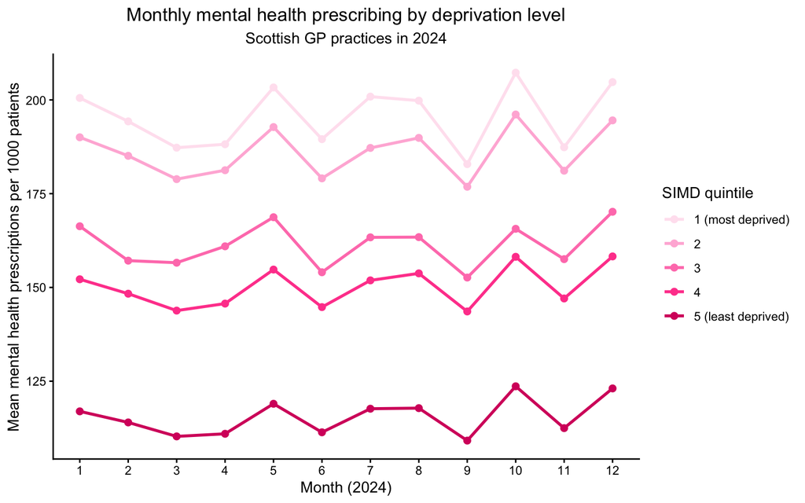

```r
ggplot(mh_month_simd,
       aes(x = month, y = mean_rate,
           colour = factor(SIMD_quintile),
           group  = SIMD_quintile)) +
  geom_line(linewidth = 1) +
  geom_point(size = 2) +
  scale_x_continuous(breaks = 1:12) +
  scale_colour_manual(
    values = pink_palette,
    name   = "SIMD quintile", # Legend name
    labels = c("1 (most deprived)", "2", "3", "4", "5 (least deprived)")) +
  labs(
    x = "Month (2024)",
    y = "Mean mental health prescriptions per 1000 patients",
    colour = "SIMD quintile",
    title = "Monthly mental health prescribing by deprivation level",
    subtitle = "Scottish GP practices in 2024"
  ) +
  theme_classic() +
  theme(
    plot.title    = element_text(hjust = 0.5),
    plot.subtitle = element_text(hjust = 0.5)
  )
```

```r
mh_rate_byclass <- mh_2024 %>%
  group_by(GPPractice, GPPracticeName, SIMD_quintile, drug_class) %>%
  summarise(
    items = sum(NumberOfPaidItems, na.rm = TRUE), # total annual items per drug class per GP
    list_size = first(PracticeListSize),
    .groups = "drop"
  ) %>%
  mutate(
    rate_per_1000 = items / list_size * 1000 # prescribing rate per 1000 patients for each drug class
  ) %>%
  filter(!is.na(SIMD_quintile))
```

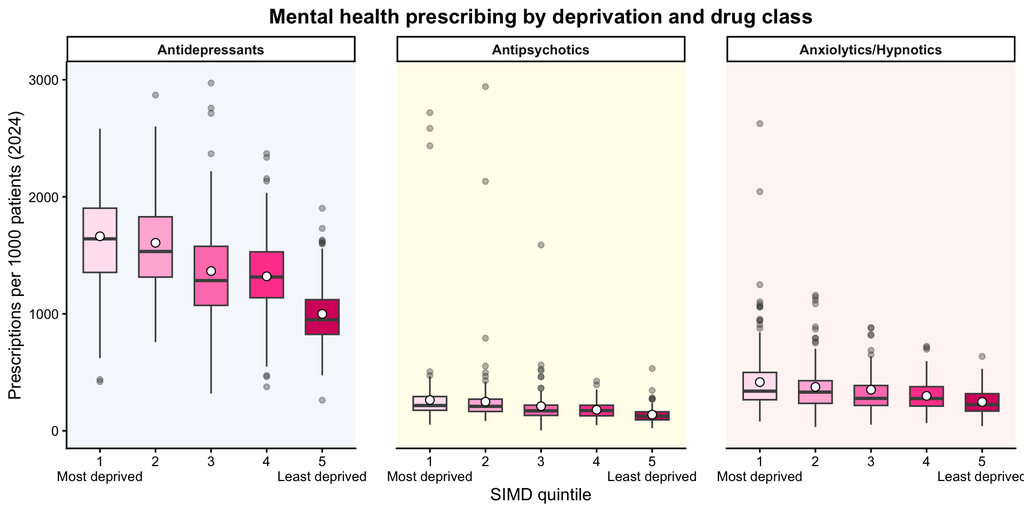

```r
bg_cols <- c(
  "Anxiolytics/Hypnotics" = "#fde0dd",  #background color
  "Antipsychotics"        = "#fff7bc",
  "Antidepressants"       = "#deebf7"
)
bg_data <- mh_rate_byclass %>%
  distinct(drug_class) %>% # one row per drug class
  mutate(bg_fill = bg_cols[drug_class]) # match each class to its background colour
ggplot(mh_rate_byclass,
       aes(x = factor(SIMD_quintile),
           y = rate_per_1000,
           fill = factor(SIMD_quintile))) +
  geom_rect( # Light background of each panel
    data = bg_data,
    aes(xmin = -Inf, xmax = Inf, # span full width of each facet panel
        ymin = -Inf, ymax = Inf), # span full height of each facet panel
    inherit.aes = FALSE, # do not inherit global aethetics
    fill = bg_data$bg_fill,   # use class-specific background colour
    alpha = 0.3) + # light transparency
  geom_boxplot(color = "grey30", width = 0.6, outlier.alpha = 0.4) +
  stat_summary(
    fun = "mean",
    geom = "point", # mean point on each box
    shape = 21,
    size = 2.5,
    fill = "white",
    color = "black"
  ) +
  facet_wrap(~ drug_class, nrow = 1) + # one row of panels, one per drug class
  coord_cartesian(ylim = c(0, 3000)) + # fix y-axis range for comparability
  scale_fill_manual(
    values = pink_palette, # SIMD quintile fill colours
    name   = "SIMD quintile",
    labels = c("1 (most deprived)", "2", "3", "4", "5 (least deprived)")) +
  scale_x_discrete(labels = c("1\nMost deprived", "2", "3", "4", "5\nLeast deprived")) +
  labs(
    x = "SIMD quintile",
    y = "Prescriptions per 1000 patients (2024)",
    title = "Mental health prescribing by deprivation and drug class"
  ) +
  theme_classic(base_size = 12) +
  theme(
    plot.title   = element_text(hjust = 0.5, face = "bold"), # center and bold title
    strip.text   = element_text(face = "bold"), # bold facet labels
    panel.spacing = unit(2, "lines"), # more space between panels
    legend.position = "none" # hide legend
  )
```

### Statistical Analysis

Across Scottish GP practices, mental health prescribing rates in 2024 showed a pronounced and statistically robust socioeconomic gradient. A Kruskal–Wallis test confirmed significant differences in prescribing across SIMD quintiles (χ² = 205.73, p < 2.2×10⁻¹⁶), and post-hoc Dunn tests indicated that practices in the most deprived quintile prescribed substantially more than those in quintiles 3–5, with adjusted p-values below 1×10⁻¹⁰, while differences between adjacent middle quintiles (Q3 vs Q4) were not significant. This pattern was highly consistent over time: when the analysis was repeated separately for each month of 2024, all twelve monthly Kruskal–Wallis tests remained strongly significant (all p < 1×10⁻³⁸), demonstrating that the deprivation gradient persisted throughout the year despite expected seasonal fluctuations in overall prescribing volume. Stratified analyses further showed that this gradient was present across all major drug classes, including antidepressants (p = 4.79×10⁻⁴⁴), antipsychotics (p = 8.88×10⁻³²), and anxiolytics/hypnotics (p = 6.15×10⁻¹⁵), indicating that inequalities were consistent across different domains of mental health treatment rather than driven by a single medication category. Overall, the prescribing rate was moderately and significantly correlated with SIMD quintile (r = –0.307, p < 0.001), confirming that GP practices in more deprived areas consistently had higher prescribing levels.

```r
library(FSA)
# 1. Overall SIMD differences
kw_overall <- kruskal.test(rate_per_1000 ~ SIMD_quintile, data = mh_rate_gp_2024) # non-parametric test for differences across 5 SIMD quintiles
print(kw_overall)
dunn_overall <- dunnTest(rate_per_1000 ~ factor(SIMD_quintile), data = mh_rate_gp_2024, method = "bonferroni") # pairwise post-hoc comparisons between SIMD quintiles
print(dunn_overall)
```

[output not shown]

```r
# 2. Monthly persistence of inequalities
kw_by_month <- mh_2024 %>%
  group_by(month, SIMD_quintile, GPPractice) %>%
  summarise(items = sum(NumberOfPaidItems, na.rm = TRUE), #monthly total items per GP
            list_size = first(PracticeListSize)) %>%  mutate(rate_per_1000 = items / list_size * 1000) %>% filter(!is.na(SIMD_quintile)) %>% group_by(month) %>%
summarise(kw = list(kruskal.test(rate_per_1000 ~ SIMD_quintile)), p_value = kw[[1]]$p.value)
print(kw_by_month)
## 3. Differences within drug classes
kw_by_class <- mh_rate_byclass %>%
  group_by(drug_class) %>%
  summarise(kw = list(kruskal.test(rate_per_1000 ~ SIMD_quintile)), p_value = kw[[1]]$p.value)
print(kw_by_class)
# 4. Correlation between deprivation and prescribing
cor_test_2024 <- cor.test(~ rate_per_1000 + SIMD_quintile, data = mh_rate_gp_2024)  # Pearson correlation between SIMD quintile and prescribing rate
print(cor_test_2024)
```

[output not shown]

# Discussion

The strong socioeconomic gradient observed in mental health prescribing across Scottish GP practices is consistent with longstanding evidence that social disadvantage is closely linked to poorer mental health outcomes. Individuals living in deprived areas experience higher rates of chronic stress, unemployment, financial insecurity, and unstable housing, which are factors known to increase the risk of depression, anxiety and severe mental illness (WHO, 2014). These structural stressors contribute to a higher underlying burden of mental illness, which may partly explain the elevated prescribing rates seen in SIMD quintile 1 practices. Another contributing mechanism relates to access to non-pharmacological care. Studies have shown that deprived communities often face barriers to psychological therapies, including longer waiting times, fewer available services, and reduced continuity of care (NHS Scotland, 2020). When therapy is less accessible, GPs may rely more heavily on pharmacological treatment, leading to higher prescribing even when clinical severity is similar. This findings also align with the “inverse care law”, the principle that healthcare availability tends to be lowest in places where need is greatest (Tudor Hart, 1971). In practice, GPs serving deprived populations manage heavier caseloads, shorter consultation times, and more complex patient needs, which may favour medication as a time-efficient intervention. Additionally, comorbid physical health conditions, which are disproportionately common in deprived groups, can exacerbate mental health symptoms and further increase prescribing rates. Importantly, the persistence of the gradient across all months and drug classes suggests that the disparity is not due to seasonal demand or condition-specific factors but reflects structural inequalities embedded across the healthcare system. Overall, these results support previous Scottish findings that deprivation strongly shapes both mental health need and patterns of treatment, highlighting the continued importance of addressing the social determinants of health.

However, limitations of the dataset should be acknowledged. First, this study uses prescribing data rather than diagnostic data, meaning it cannot determine whether higher prescribing reflects higher true prevalence of mental illness or differences in treatment pathways. Second, SIMD is measured at the postcode level, which may mask within-area variation and lead to ecological bias. Third, the dataset does not include ethnicity, consultation length, GP workload, or access to psychological therapies, all of which may influence prescribing rates but cannot be assessed here. Finally, the analysis does not capture whether prescriptions were appropriate, effective, or adhered to, and therefore cannot make clinical quality judgement.

Future research should address these gaps by linking prescribing records with clinical diagnostic data, socioeconomic histories, and patient-level demographics, which would allow for a more fine-grained understanding of need versus supply effects. Integrating workforce measures, such as GP staffing levels, waiting times, practice funding, and access to talking therapies, would also help clarify how service constraints shape prescribing behaviour. Spatial modelling and longitudinal methods could further explore whether inequalities are widening or narrowing over time, while qualitative work with practitioners could shed light on decision-making under resource pressure. Collectively, these next steps would enable a more comprehensice assessment of how structural deprivation translates into differential patterns of mental-health treatment across Scotland.

# Conclusion

This analysis shows a clear and persistent socioeconomic gradient in mental health prescribing across Scottish GP practices, with markedly higher rates in the most deprived communities. The pattern is consistent across months and drug classes, and the statistical tests strongly support an association between deprivation and increased prescribing. These findings suggest that structural inequalities continue to shape both the burden of mental illness and the treatment patients receive. Although prescribing data cannot reveal underlying clinical need or access to alternative therapies, the results underline the importance of improving mental health support in deprived areas and addressing the broader social and economic conditions that contribute to poor mental health across Scotland.

# References

Public Health Scotland (2020). Psychological therapies waiting times - Quarter ending June 2020 - Psychological therapies waiting times - Publications - Public Health Scotland. [online] Available at: https://publichealthscotland.scot/publications/psychological-therapies-waiting-times/psychological-therapies-waiting-times-quarter-ending-june-2020/.

Public Health Scotland (2021). Psychological therapies: Waiting times. Edinburgh: Public Health Scotland. Available at: https://publichealthscotland.scot/publications/psychological-therapies-waiting-times/ (Accessed: 23 November 2025).

Public Health Scotland (2022). Mental health: Incidence and inequalities overview. Edinburgh: Public Health Scotland. Available at: https://publichealthscotland.scot/our-areas-of-work/mental-health/ (Accessed: 23 November 2025).

Tudor Hart, J. (1971). The Inverse Care Law. The Lancet, [online] 297(7696), pp.405–412. Available at: doi:https://doi.org/10.1016/s0140-6736(71)92410-x.

World Health Organization (2014). Social Determinants of Mental Health. [online] www.who.int. Available at: https://www.who.int/publications/i/item/9789241506809.